# Part II - Ford GoBike System Data Analysis

## by Pius Uagbae Ejodamen

## Investigation Overview

> This data analysis is on the Ford GoBike System data set. The dataset was visually and programmatically assessed, cleaned, and analysed using various charts to gain insights.

> We see from charts that male customers spend more time riding than male subscribers.

> Saturdays and Sundays witnessed more ride duration, despite the significantly lesser number of riders on Saturdays and Sundays. Probably there are lesser demands for bikes, resulting in more time available for those needing bikes to come take them.

> From the pattern in data, we can perceive that subscribers are workers who ride to work on weekdays since there is a regular ride time during this period. They spend more time at weekends, probably for fun rides.

> Among the known age groups, riders in the Elder age group spend lesser time riding. Also, they take a little more time during riding to arrive at their destination. Whereas, the Youth were fastest covering their route!

## Dataset Overview

> The Ford GoBike System data set includes information about individual rides made in a bike-sharing system covering the greater San Francisco Bay area.

> There 183412 records and 16 features in the dataset. Participants in the ride sharing were either Subscribers or customers and were aged from 18 and above. No underage rode the bikes! The bikes were available for riding at various times - from morning to night!

> Some of the data had either quality issues or tidyness issues. The include:
> - start_time and end_time should be converted to datetime datatype
> - convert start_station_id, end_station_id, bike_id datatype to string
> - There are empty (NaN) entries in some attributes. This should be looked into.
> - Create new columns - hour, day - extracted from the 'start_time' date column
> - Birth year alone donot state the age. Create another column to contain the ages of each rider.

> It was important to clean the data so as to be able analyse them correctly.

## PREFERED TIME FOR RIDING

Bikes are available for ride irrespective of time! We categorize time based on standard 24hours clock system. Notably, hours of 4am and 12noon is Morning, hours between 12noon and 4pm is Afternoon, between 4pm to 9pm is evening, while other time is Night.

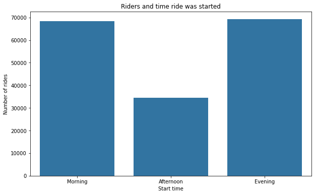

## IMPACT OF AGE

Data shows that riders of different ages partook in collecting bikes. The age groups are categorised as Youth (18- 25), Adult(26 - 59), Elder(>59). However, there were some who did not state their dates of births. We are interested to examine their behavioural pattern, hence they are categorized as 'Unspecified'.

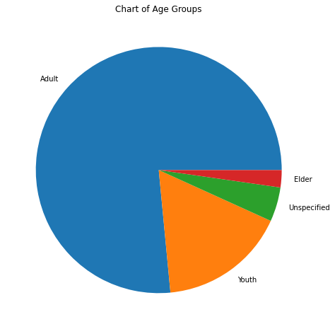

## BIKE AVAILABILITY

We investigate the availability of bikes. This is important, for example, when deciding which age group will often be given preference if returning of bikes is priority.

The age group that spends less time riding is of interest.

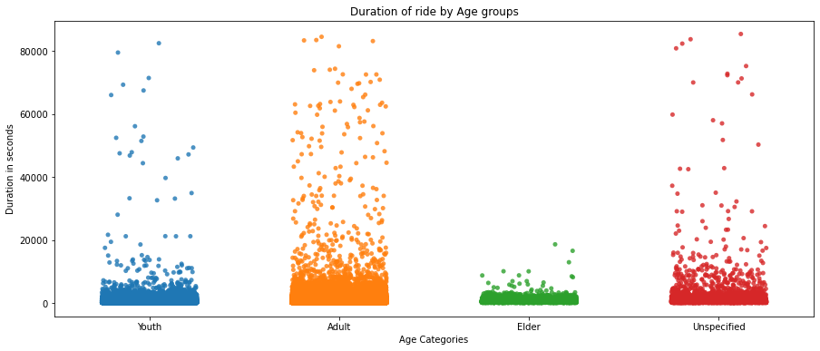

## MEMBERSHIP STATUS AND RIDE PATTERN

In the Ford GoBike system, membership status is either 'Subscriber' or 'Customer'. We investigate their ride pattern with regards to the riding duration and which day of the week.

Adequate knowledge of this pattern is necessary to understand which category spends more time riding per day!

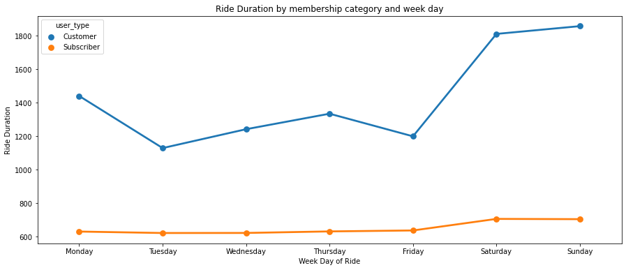